# 利用Python做数据分析-四-Numpy基础：数组与向量化计算

## 4.0 Numpy与Python内建区别

- numpy的算法库是用C写的，所以在操作数据内存时，不需要任何类型检查或者其他管理操作
- numpy在内部将数据结构存储在连续的内存块上
- numpy可以针对全量数组进行复杂计算而不需要写Python循坏
- numpy数组使用的内存量也小于其他Python内建序列

写个数组包含100万个整数

```python
import numpy as np
my_arr = np.arange(1000000)
my_list = list(range(1000000))
```

```python
%time for _ in range(10):my_arr2 = my_arr * 2
```

```
Wall time: 31.9 ms
```

```python
%time for _ in range(10):my_list2 = [x * 2 for x in my_list]
```

```
Wall time: 812 ms
```

## 4.1 NumPy ndarray：多维数组对象

```python
import numpy as np
data = np.random.rand(2,3)
data
```

```
array([[0.67437143, 0.46781136, 0.34048825],
       [0.88015018, 0.16267641, 0.48478275]])
```

```python
data.shape
```

```
(2, 3)
```

```python
data.dtype
```

```
dtype('float64')
```

一个ndarray中每一个元素均为相同类型。  
每一个数组都有一个shape属性，用来表征数组每一维度  
每一个数组都有一个dtype属性，用来表征数组的数据类型

> 数组，NumPy数组，ndarray,他们都是表示同一个对象：`ndarray对象`

### 4.1.1 生成ndarray

最简单的方式使用`array`函数

```python
data1= [6, 7.5, 8, 0, 1]
arr1 = np.array(data1)
arr1
```

```
array([6. , 7.5, 8. , 0. , 1. ])
```

```python
data2= [[1,2,3],[4,5,6]]
arr2 = np.array(data2)
arr2
```

```
array([[1, 2, 3],
       [4, 5, 6]])
```

arange是Python内建函数range的数组版

```python
np.arange(15)
```

```
array([ 0,  1,  2,  3,  4,  5,  6,  7,  8,  9, 10, 11, 12, 13, 14])
```

##### 数组生成函数

| 函数名 | 描述 |
| --- | --- |
| array | 将输入数据（可以是列表，元组，数组以及其他序列）转换为ndarray,如不显示指明数据类型，将自动推断；默认复制所有的输入数据 |
| asarray | 将输入数据转换为ndarray,如果输入已经是ndarray则不再复制 |
| arange | Python内建函数range的数组版,返回一个数组 |
| ones | 全1数组 |
| zeros | 全0数组 |
| empty | 空数组 |
| full | 指定数字数组 |

### 4.1.2 ndarray的数据类型

数据类型，即`dtype`,是一个特殊的对象，它包含了ndarray需要为某一种类的数据所申请的内存信息。

```python
import numpy as np
arr1 = np.array([1,2,3],dtype = np.float64)
arr1.dtype
```

```
dtype('float64')
```

可以使用`astype`方法显示转换数组的数据类型

```python
arr = np.array([1,2,3,4])
arr.dtype
```

```
dtype('int32')
```

```python
float_arr = arr.astype(np.float64)
float_arr.dtype
```

```
dtype('float64')
```

### 4.1.4 基础索引与切片

在二维数组中，axis = 0 可以看作“行”，axis = 1 看作“列”

### 4.1.5 布尔索引

```python
name = np.array(['Bob','ADA','Will','BoB','Bob','Joe'])
#布尔数组的长度必须和数组轴索引长度一直
data = np.random.rand(6,4)
name
```

```
array(['Bob', 'ADA', 'Will', 'BoB', 'Bob', 'Joe'], dtype='<U4')
```

```python
data
```

```
array([[0.68825499, 0.22919014, 0.57097642, 0.48120528],
       [0.51786581, 0.61303225, 0.62523369, 0.83754164],
       [0.27996152, 0.10827856, 0.26305046, 0.9735058 ],
       [0.3811697 , 0.06500952, 0.79612815, 0.65980703],
       [0.13931857, 0.09140437, 0.40406567, 0.05216862],
       [0.11567688, 0.37322179, 0.53712485, 0.15310537]])
```

```python
name == 'Bob'
```

```
array([ True, False, False, False,  True, False])
```

```python
data[name == 'Bob']
```

```
array([[0.68825499, 0.22919014, 0.57097642, 0.48120528],
       [0.13931857, 0.09140437, 0.40406567, 0.05216862]])
```

```python
data[name == 'Bob',2:]
```

```
array([[0.57097642, 0.48120528],
       [0.40406567, 0.05216862]])
```

为了选择'Bob'以外的数据，可以使用！= 或在条件表达式前使用 ~ 对条件取反

```python
data[~(name == 'Bob')]
```

```
array([[0.51786581, 0.61303225, 0.62523369, 0.83754164],
       [0.27996152, 0.10827856, 0.26305046, 0.9735058 ],
       [0.3811697 , 0.06500952, 0.79612815, 0.65980703],
       [0.11567688, 0.37322179, 0.53712485, 0.15310537]])
```

```python
data[name != 'Bob']
```

```
array([[0.51786581, 0.61303225, 0.62523369, 0.83754164],
       [0.27996152, 0.10827856, 0.26305046, 0.9735058 ],
       [0.3811697 , 0.06500952, 0.79612815, 0.65980703],
       [0.11567688, 0.37322179, 0.53712485, 0.15310537]])
```

利用一维布尔数值数组对每一行设置数值

```python
data[name != 'Will'] = 7
data
```

```
array([[7.        , 7.        , 7.        , 7.        ],
       [7.        , 7.        , 7.        , 7.        ],
       [0.27996152, 0.10827856, 0.26305046, 0.9735058 ],
       [7.        , 7.        , 7.        , 7.        ],
       [7.        , 7.        , 7.        , 7.        ],
       [7.        , 7.        , 7.        , 7.        ]])
```

### 4.1.7 数组转置和换轴

```python
arr = np.arange(15).reshape((3,5))
arr
```

```
array([[ 0,  1,  2,  3,  4],
       [ 5,  6,  7,  8,  9],
       [10, 11, 12, 13, 14]])
```

```python
arr.T
```

```
array([[ 0,  5, 10],
       [ 1,  6, 11],
       [ 2,  7, 12],
       [ 3,  8, 13],
       [ 4,  9, 14]])
```

```python
arr = np.arange(16).reshape((2,2,4))
arr
```

```
array([[[ 0,  1,  2,  3],
        [ 4,  5,  6,  7]],

       [[ 8,  9, 10, 11],
        [12, 13, 14, 15]]])
```

```python
arr.transpose((1,0,2))
```

```
array([[[ 0,  1,  2,  3],
        [ 8,  9, 10, 11]],

       [[ 4,  5,  6,  7],
        [12, 13, 14, 15]]])
```

## 4.2 快速的逐元素数组函数

> 通用函数：ufunc,是一种在ndarray数据中进行逐元素操作的函数

```python
x = np.random.randn(8)
y = np.random.randn(8)
np.maximum(x,y)
#numpy.maximum逐个元素地将x和y中的元素最大值计算出来
```

```
array([ 0.70082525, -0.21172791,  0.76273072,  0.04472001,  0.93080526,
        1.35814834, -0.43365833,  1.20028655])
```

## 4.3 使用数组进行面向数组编程

使用numpy数组可以利用简单的数组表达式完成多种数据操作任务，而无须写大量的循环。  
这种利用数组表达式来代替显示循环的方法，称为向量化。

```python
points = np.arange(-5, 5, 0.01)
xs, ys = np.meshgrid(points, points)
#np.meshgrid从坐标向量返回坐标矩阵。
ys
```

```
array([[-5.  , -5.  , -5.  , ..., -5.  , -5.  , -5.  ],
       [-4.99, -4.99, -4.99, ..., -4.99, -4.99, -4.99],
       [-4.98, -4.98, -4.98, ..., -4.98, -4.98, -4.98],
       ...,
       [ 4.97,  4.97,  4.97, ...,  4.97,  4.97,  4.97],
       [ 4.98,  4.98,  4.98, ...,  4.98,  4.98,  4.98],
       [ 4.99,  4.99,  4.99, ...,  4.99,  4.99,  4.99]])
```

```python
z = np.sqrt(xs ** 2 + ys ** 2)
z
```

```
array([[7.07106781, 7.06400028, 7.05693985, ..., 7.04988652, 7.05693985,
        7.06400028],
       [7.06400028, 7.05692568, 7.04985815, ..., 7.04279774, 7.04985815,
        7.05692568],
       [7.05693985, 7.04985815, 7.04278354, ..., 7.03571603, 7.04278354,
        7.04985815],
       ...,
       [7.04988652, 7.04279774, 7.03571603, ..., 7.0286414 , 7.03571603,
        7.04279774],
       [7.05693985, 7.04985815, 7.04278354, ..., 7.03571603, 7.04278354,
        7.04985815],
       [7.06400028, 7.05692568, 7.04985815, ..., 7.04279774, 7.04985815,
        7.05692568]])
```

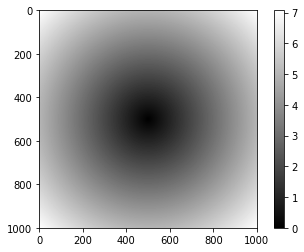

```python
import matplotlib.pyplot as plt
plt.imshow(z, cmap = plt.cm.gray)
plt.colorbar()
```

### 4.3.1 将条件逻辑作为数组操作

```
np.where() #是三元表达式 x if condition else y的向量化版本。
where(condition, [x, y]) 当condition为True时，返回 x ， 否则返回 y。

其实，在x, y 为一维数组时，就相当于：

[xv if c else yv for (c,xv,yv) in zip(condition,x,y)]
```

```python
xarr = np.array([1.1, 1.2, 1.3, 1.4, 1.5])
yarr = np.array([2.1, 2.2, 2.3, 2.4, 2.5])
cond = np.array([True, False, True, True, False])
```

```python
result = [(x if c else y)
             for x,y,c in zip(xarr, yarr, cond)] # zip 打包成元组
result
```

```
[1.1, 2.2, 1.3, 1.4, 2.5]
```

如果数组很大的，用Python会很慢；当数组是多维时，就无法奏效  
使用numpy.where就可以简单的完成任务

```python
result = np.where(cond,xarr,yarr)
result
```

```
array([1.1, 2.2, 1.3, 1.4, 2.5])
```

`numpy.where`的第二、三个参数并不需要是数组，他们可以是标量

```python
arr = np.random.randn(5,5)
arr
```

```
array([[ 0.01786416, -0.99554956, -0.54638153,  0.45541548, -0.3549564 ],
       [-1.704533  ,  0.50345769,  0.4041796 , -0.70324849, -0.47419683],
       [ 1.19644685, -0.20333666,  0.99451829, -0.6423531 , -0.24048183],
       [-1.35905338, -1.99046664,  1.18922794,  0.15559158,  1.10507208],
       [-1.46153496,  0.59785011, -1.06788123, -1.09992268, -1.84517347]])
```

```python
arr > 0
```

```
array([[ True, False, False,  True, False],
       [False,  True,  True, False, False],
       [ True, False,  True, False, False],
       [False, False,  True,  True,  True],
       [False,  True, False, False, False]])
```

```python
np.where(arr > 0, -2, 2) # arr > 0 ？ -2 ： 2
```

```
array([[-2,  2,  2, -2,  2],
       [ 2, -2, -2,  2,  2],
       [-2,  2, -2,  2,  2],
       [ 2,  2, -2, -2, -2],
       [ 2, -2,  2,  2,  2]])
```

### 4.3.2 数学和统计方法

```python
arr = np.random.randn(6,6)
arr
```

```
array([[ 0.32054855,  0.28517116, -0.39771976,  0.69355599, -0.65833403,
         0.26266084],
       [-0.43085327,  0.57827006, -0.49321898, -0.46611546, -1.74371233,
        -0.04516856],
       [ 0.80561389,  0.22562953, -0.37257883, -1.15251276, -0.42069828,
         0.33594484],
       [-0.19737563,  0.25350161, -0.70413903,  0.02391027,  1.46337946,
        -0.25800273],
       [ 1.98215423,  1.08261488, -0.32213662,  1.19578897,  1.59983136,
         0.57078381],
       [-0.90647754,  0.3032904 , -1.66508061,  0.46877695,  1.39097924,
         2.08839516]])
```

```python
arr.mean() #所有数的平均值
```

```
0.1582410217596215
```

```python
#arr.mean(axis = 1) #纵坐标的平均值 与下面等价
arr.mean(1)
```

```
array([ 0.08431379, -0.43346642, -0.0964336 ,  0.09687899,  1.01817277,
        0.2799806 ])
```

| 方法 | 描述 |
| --- | --- |
| sum | 沿着轴向计算所有元素的累和，0长度的数组累和为NaN |
| mean | 数学平均，0长度的数组平均值为NaN |
| sta,var | 标准差，方差 |
| min,max | 最小值，最大值 |
| argmin,argmax | ..,..的位置 |
| cumsum | 从0开始元素的累积和 |
| cumprod | .1.......累积积 |

```python
arr = np.random.randn(4,5)
arr
```

```
array([[ 1.4824802 ,  1.65622766,  0.26822741,  0.4190312 , -0.21062045],
       [-1.37060122,  0.08400981,  1.55374481,  2.28920071, -0.78321072],
       [-1.55910942, -1.40267169, -0.85947895, -0.73384311, -1.26494977],
       [ 1.52517271, -0.28901345,  1.8628579 , -1.54060651, -0.66100923]])
```

```python
arr.cumprod()
```

```
array([ 1.4824802 ,  2.45532471,  0.6585854 ,  0.27596783, -0.05812447,
        0.07966547,  0.00669268,  0.01039872,  0.02380475, -0.01864414,
        0.02906825, -0.04077321,  0.03504372, -0.02571659,  0.0325302 ,
        0.04961417, -0.01433916, -0.02671182,  0.04115241, -0.02720212])
```

### 4.3.3 布尔值数组的方法

对于布尔数组

- any检查数组中是否至少有一个True
- all检查是否每个值都是True

```python
bools = np.array([False,True,False,True])
bools.any()
```

```
True
```

```python
bools.all()
```

```
False
```

### 4.3.4 排序

numpy数组可以使用sort方法按位置进行排序

- sort(0)按行排序
- sort(1)按列排序

### 4.3.5 唯一值与其他集合逻辑

```python
num = np.array([1 , 3,4,5,532,32,3,1])
num
```

```
array([  1,   3,   4,   5, 532,  32,   3,   1])
```

```python
np.unique(num)
```

```
array([  1,   3,   4,   5,  32, 532])
```